# Fibraxine - Analiza statystyczna dla T. Banasiewicza

Autor: W. Francuzik

## kwestie do weryfikacji:

### - czy grupy są porównywalne pod względem płci, wieku i BMI

```r
sex <- df %>%
  group_by(grupa,płeć) %>%
  summarize(n = n()) %>%
  spread(key = `płeć`, value = n)

sex
```

```
## # A tibble: 2 x 3
## # Groups:   grupa [2]
##   grupa       k     m
##   <fct>   <int> <int>
## 1 placebo    28    30
## 2 verum      33    30
```

```r
chisq.test(sex[,2:3])
```

```
##
##  Pearson's Chi-squared test with Yates' continuity correction
##
## data:  sex[, 2:3]
## X-squared = 0.072474, df = 1, p-value = 0.7878
```

BRAK różnic względem płci

```r
age <- df %>%
  group_by(grupa) %>%
  summarize(sr_wiek = mean(wiek),
            sd_wiek = sd(wiek))

df %>%
  t.test(formula = wiek~grupa,data=.)
```

```
##
##  Welch Two Sample t-test
##
## data:  wiek by grupa
## t = -0.087328, df = 118.72, p-value = 0.9306
## alternative hypothesis: true difference in means is not equal to 0
## 95 percent confidence interval:
##  -2.824926  2.586284
## sample estimates:
## mean in group placebo   mean in group verum
##              64.89655              65.01587
```

Nie ma różnic w wieku

```r
df %>% group_by(grupa) %>%
  summarise(sr_BMI = mean(BMI),
            sd_BMI = sd(BMI))
```

```
## # A tibble: 2 x 3
##   grupa   sr_BMI sd_BMI
##   <fct>    <dbl>  <dbl>
## 1 placebo   33.3   2.75
## 2 verum     32.8   2.80
```

```r
t.test(BMI~grupa, df)
```

```
##
##  Welch Two Sample t-test
##
## data:  BMI by grupa
## t = 0.91116, df = 118.46, p-value = 0.3641
## alternative hypothesis: true difference in means is not equal to 0
## 95 percent confidence interval:
##  -0.539308  1.458629
## sample estimates:
## mean in group placebo   mean in group verum
##              33.25172              32.79206
```

Brak różnic w BMI

### - czy jest różnica pomiędzy średnią ilością wypróżnień przed terapią W0 i po 3 mcach W1 dla wszystkich badanych oraz osobno dla grupy żółtej i zielonej

dla wszystkich :

```r
# sloppy
wilcox.test(df$`W0 średnia dzienna ilość wypróżnień w ciągu ostatnich 7 dni`,
       df$`W1 średnia dzienna ilość wypróżnień w ciągu ostatnich 7 dni`)
```

```
##
##  Wilcoxon rank sum test with continuity correction
##
## data:  df$`W0 średnia dzienna ilość wypróżnień w ciągu ostatnich 7 dni` and df$`W1 średnia dzienna ilość wypróżnień w ciągu ostatnich 7 dni`
## W = 4032, p-value = 1.404e-07
## alternative hypothesis: true location shift is not equal to 0
```

Jest różnica.

Grupa PLACEBO:

```r
df %>%
  filter(grupa == "placebo") %>%
{wilcox.test(.$`W0 średnia dzienna ilość wypróżnień w ciągu ostatnich 7 dni`,
       .$`W1 średnia dzienna ilość wypróżnień w ciągu ostatnich 7 dni`)}
```

```
##
##  Wilcoxon rank sum test with continuity correction
##
## data:  .$`W0 średnia dzienna ilość wypróżnień w ciągu ostatnich 7 dni` and .$`W1 średnia dzienna ilość wypróżnień w ciągu ostatnich 7 dni`
## W = 1310.5, p-value = 0.279
## alternative hypothesis: true location shift is not equal to 0
```

W placebo BRAK różnic.

Grupa VERUM:

```r
df %>%
  filter(grupa == "verum") %>%
{wilcox.test(.$`W0 średnia dzienna ilość wypróżnień w ciągu ostatnich 7 dni`,
       .$`W1 średnia dzienna ilość wypróżnień w ciągu ostatnich 7 dni`)}
```

```
##
##  Wilcoxon rank sum test with continuity correction
##
## data:  .$`W0 średnia dzienna ilość wypróżnień w ciągu ostatnich 7 dni` and .$`W1 średnia dzienna ilość wypróżnień w ciągu ostatnich 7 dni`
## W = 650.5, p-value = 2.371e-10
## alternative hypothesis: true location shift is not equal to 0
```

Ogromna różnica!

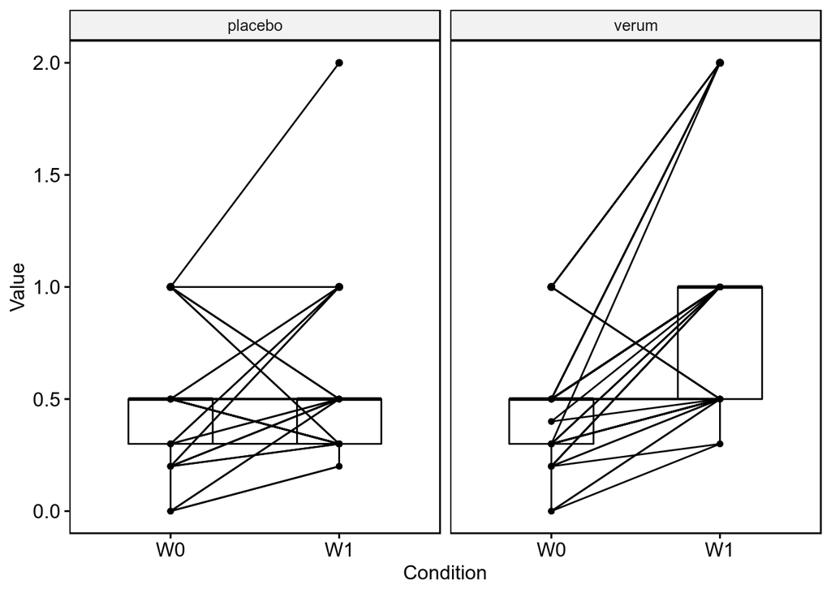

```r
df2 <- df %>%
  select(pacjent,
         grupa,
         `W0 średnia dzienna ilość wypróżnień w ciągu ostatnich 7 dni`,
         `W1 średnia dzienna ilość wypróżnień w ciągu ostatnich 7 dni`) %>%
  gather(key = "wizyta",
         value = "srednia_wypr_dzienne",
         3:4) %>%
 mutate(wizyta = factor(wizyta))

levels(df2$wizyta) <- c("W0","W1")
  df2 %>%
  ggpubr::ggpaired(x = "wizyta",
                   y = "srednia_wypr_dzienne",
                   facet.by = "grupa")
```

### - czy jest różnica pomiędzy konsystencją stolca przed terapią W0 i po 3 mcach W1 dla wszystkich badanych oraz osobno dla grupy żółtej i zielonej

Wszyscy:

```r
wilcox.test(df$`W0 średnia konsystencja stolca w ciągu ostatnich 7 dni (skala Bristol )`,
            df$`W1 średnia konsystencja stolca w ciągu ostatnich 7 dni (skala Bristol )`)
```

```
##
##  Wilcoxon rank sum test with continuity correction
##
## data:  df$`W0 średnia konsystencja stolca w ciągu ostatnich 7 dni (skala Bristol )` and df$`W1 średnia konsystencja stolca w ciągu ostatnich 7 dni (skala Bristol )`
## W = 4577.5, p-value = 4.189e-06
## alternative hypothesis: true location shift is not equal to 0
```

jest różnica między wizytami dla wszystkich.

PLACEBO:

```r
df %>%
  filter(grupa == "placebo") %>%
  {wilcox.test(.$`W0 średnia konsystencja stolca w ciągu ostatnich 7 dni (skala Bristol )`,
             .$`W1 średnia konsystencja stolca w ciągu ostatnich 7 dni (skala Bristol )`)}
```

```
##
##  Wilcoxon rank sum test with continuity correction
##
## data:  .$`W0 średnia konsystencja stolca w ciągu ostatnich 7 dni (skala Bristol )` and .$`W1 średnia konsystencja stolca w ciągu ostatnich 7 dni (skala Bristol )`
## W = 1306, p-value = 0.1626
## alternative hypothesis: true location shift is not equal to 0
```

Tu brak

VERUM:

```r
df %>%
  filter(grupa == "verum") %>%
  {wilcox.test(.$`W0 średnia konsystencja stolca w ciągu ostatnich 7 dni (skala Bristol )`,
             .$`W1 średnia konsystencja stolca w ciągu ostatnich 7 dni (skala Bristol )`)}
```

```
##
##  Wilcoxon rank sum test with continuity correction
##
## data:  .$`W0 średnia konsystencja stolca w ciągu ostatnich 7 dni (skala Bristol )` and .$`W1 średnia konsystencja stolca w ciągu ostatnich 7 dni (skala Bristol )`
## W = 952, p-value = 3.733e-07
## alternative hypothesis: true location shift is not equal to 0
```

JEST!

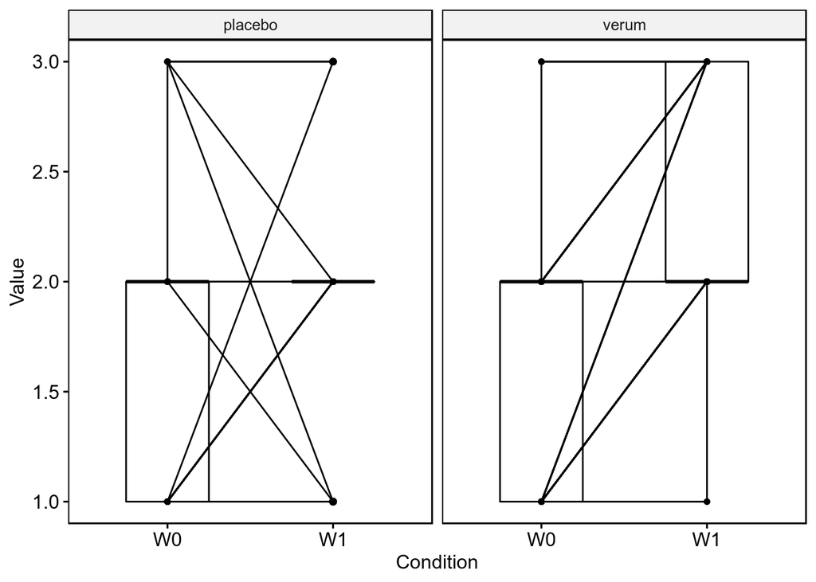

```r
df2 <- df %>%
  select(pacjent,
         grupa,
         `W0 średnia konsystencja stolca w ciągu ostatnich 7 dni (skala Bristol )`,
         `W1 średnia konsystencja stolca w ciągu ostatnich 7 dni (skala Bristol )`) %>%
  gather(key = "wizyta",
         value = "srednia_konsyst_stolca",
         3:4) %>%
 mutate(wizyta = factor(wizyta))

levels(df2$wizyta) <- c("W0","W1")
  df2 %>%
  ggpubr::ggpaired(x = "wizyta",
                   y = "srednia_konsyst_stolca",
                   facet.by = "grupa")
```

### - czy jest róznica pomiędzy nasileniem dolegliwości bólowych przed terapią W0 i po 3 mcach W1 dla wszystkich badanych oraz osobno dla grupy żółtej i zielonej

Wszyscy:

```r
wilcox.test(df$`W0 występowanie/brak bólu brzucha i jego nasilenie w skali VAS w ciągu ostatnich 7 dni`,
            df$`W1 występowanie/brak bólu brzucha i jego nasilenie w skali VAS średnio w ciągu badania w przeliczeniu na 7 dni`)
```

```
##
##  Wilcoxon rank sum test with continuity correction
##
## data:  df$`W0 występowanie/brak bólu brzucha i jego nasilenie w skali VAS w ciągu ostatnich 7 dni` and df$`W1 występowanie/brak bólu brzucha i jego nasilenie w skali VAS średnio w ciągu badania w przeliczeniu na 7 dni`
## W = 10340, p-value = 7.59e-16
## alternative hypothesis: true location shift is not equal to 0
```

jest różnica między wizytami dla wszystkich.

PLACEBO:

```r
df %>%
  filter(grupa == "placebo") %>%
  {wilcox.test(.$`W0 występowanie/brak bólu brzucha i jego nasilenie w skali VAS w ciągu ostatnich 7 dni`,
             .$`W1 występowanie/brak bólu brzucha i jego nasilenie w skali VAS średnio w ciągu badania w przeliczeniu na 7 dni`)}
```

```
##
##  Wilcoxon rank sum test with continuity correction
##
## data:  .$`W0 występowanie/brak bólu brzucha i jego nasilenie w skali VAS w ciągu ostatnich 7 dni` and .$`W1 występowanie/brak bólu brzucha i jego nasilenie w skali VAS średnio w ciągu badania w przeliczeniu na 7 dni`
## W = 2287.5, p-value = 4.254e-07
## alternative hypothesis: true location shift is not equal to 0
```

Tu też

VERUM:

```r
df %>%
  filter(grupa == "verum") %>%
  {wilcox.test(.$`W0 występowanie/brak bólu brzucha i jego nasilenie w skali VAS w ciągu ostatnich 7 dni`,
             .$`W1 występowanie/brak bólu brzucha i jego nasilenie w skali VAS średnio w ciągu badania w przeliczeniu na 7 dni`)}
```

```
##
##  Wilcoxon rank sum test with continuity correction
##
## data:  .$`W0 występowanie/brak bólu brzucha i jego nasilenie w skali VAS w ciągu ostatnich 7 dni` and .$`W1 występowanie/brak bólu brzucha i jego nasilenie w skali VAS średnio w ciągu badania w przeliczeniu na 7 dni`
## W = 2911.5, p-value = 1.782e-10
## alternative hypothesis: true location shift is not equal to 0
```

I tu.

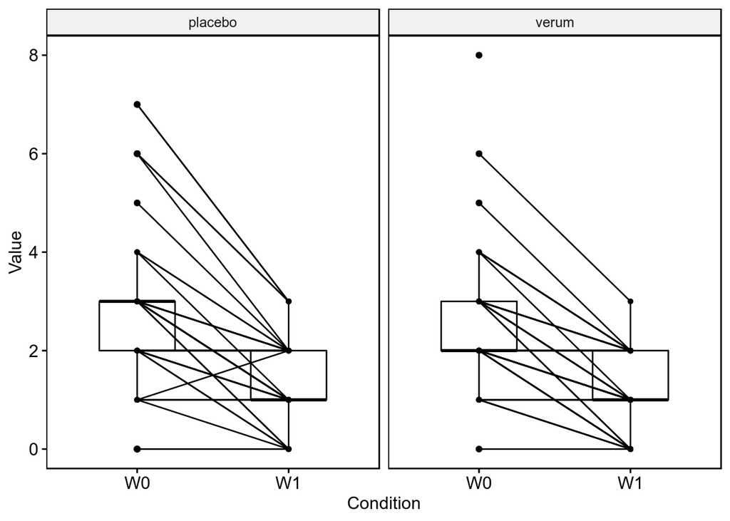

```r
df2 <- df %>%
  select(pacjent,
         grupa,
         `W0 występowanie/brak bólu brzucha i jego nasilenie w skali VAS w ciągu ostatnich 7 dni`,
         `W1 występowanie/brak bólu brzucha i jego nasilenie w skali VAS średnio w ciągu badania w przeliczeniu na 7 dni`) %>%
  gather(key = "wizyta",
         value = "srednia_konsyst_stolca",
         3:4) %>%
 mutate(wizyta = factor(wizyta))

levels(df2$wizyta) <- c("W0","W1")
  df2 %>%
  ggpubr::ggpaired(x = "wizyta",
                   y = "srednia_konsyst_stolca",
                   facet.by = "grupa")
```

### - czy jest róznica pomiędzy ocena jakość życia według polskiej wersji kwestionariusza Gastrointestinal Quality of Life Index (GIQLI) przed terapią W0 i po 3 mcach W1 dla wszystkich badanych oraz osobno dla grupy żółtej i zielonej

Wszyscy:

```r
wilcox.test(df$`W0 - jakość życia według polskiej wersji kwestionariusza Gastrointestinal Quality of Life Index (GIQLI) (zgodnie ze skalą w ciągu ostatnich 2 tygodni`,
            df$`W1 - jakość życia według polskiej wersji kwestionariusza Gastrointestinal Quality of Life Index (GIQLI) (zgodnie ze skalą w ciągu ostatnich 2 tygodni`)
```

```
##
##  Wilcoxon rank sum test with continuity correction
##
## data:  df$`W0 - jakość życia według polskiej wersji kwestionariusza Gastrointestinal Quality of Life Index (GIQLI) (zgodnie ze skalą w ciągu ostatnich 2 tygodni` and df$`W1 - jakość życia według polskiej wersji kwestionariusza Gastrointestinal Quality of Life Index (GIQLI) (zgodnie ze skalą w cią…
## W = 2397, p-value < 2.2e-16
## alternative hypothesis: true location shift is not equal to 0
```

jest różnica między wizytami dla wszystkich.

PLACEBO:

```r
df %>%
  filter(grupa == "placebo") %>%
  {wilcox.test(.$`W0 - jakość życia według polskiej wersji kwestionariusza Gastrointestinal Quality of Life Index (GIQLI) (zgodnie ze skalą w ciągu ostatnich 2 tygodni`,
             .$`W1 - jakość życia według polskiej wersji kwestionariusza Gastrointestinal Quality of Life Index (GIQLI) (zgodnie ze skalą w ciągu ostatnich 2 tygodni`)}
```

```
##
##  Wilcoxon rank sum test with continuity correction
##
## data:  .$`W0 - jakość życia według polskiej wersji kwestionariusza Gastrointestinal Quality of Life Index (GIQLI) (zgodnie ze skalą w ciągu ostatnich 2 tygodni` and .$`W1 - jakość życia według polskiej wersji kwestionariusza Gastrointestinal Quality of Life Index (GIQLI) (zgodnie ze skalą w ciągu…
## W = 687, p-value = 1.492e-06
## alternative hypothesis: true location shift is not equal to 0
```

Tu też

VERUM:

```r
df %>%
  filter(grupa == "verum") %>%
  {wilcox.test(.$`W0 - jakość życia według polskiej wersji kwestionariusza Gastrointestinal Quality of Life Index (GIQLI) (zgodnie ze skalą w ciągu ostatnich 2 tygodni`,
             .$`W1 - jakość życia według polskiej wersji kwestionariusza Gastrointestinal Quality of Life Index (GIQLI) (zgodnie ze skalą w ciągu ostatnich 2 tygodni`)}
```

```
##
##  Wilcoxon rank sum test with continuity correction
##
## data:  .$`W0 - jakość życia według polskiej wersji kwestionariusza Gastrointestinal Quality of Life Index (GIQLI) (zgodnie ze skalą w ciągu ostatnich 2 tygodni` and .$`W1 - jakość życia według polskiej wersji kwestionariusza Gastrointestinal Quality of Life Index (GIQLI) (zgodnie ze skalą w ciągu…
## W = 425, p-value = 5.683e-13
## alternative hypothesis: true location shift is not equal to 0
```

I tu.

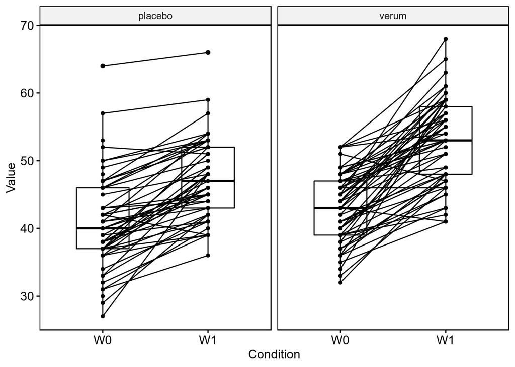

```r
df2 <- df %>%
  select(pacjent,
         grupa,
         `W0 - jakość życia według polskiej wersji kwestionariusza Gastrointestinal Quality of Life Index (GIQLI) (zgodnie ze skalą w ciągu ostatnich 2 tygodni`,
         `W1 - jakość życia według polskiej wersji kwestionariusza Gastrointestinal Quality of Life Index (GIQLI) (zgodnie ze skalą w ciągu ostatnich 2 tygodni`) %>%
  gather(key = "wizyta",
         value = "srednia_konsyst_stolca",
         3:4) %>%
 mutate(wizyta = factor(wizyta))

levels(df2$wizyta) <- c("W0","W1")
  df2 %>%
  ggpubr::ggpaired(x = "wizyta",
                   y = "srednia_konsyst_stolca",
                   facet.by = "grupa")
```

### - czy jest róznica pomiędzy ilością wizyt ambulatoryjnych pomiędzy grupami żółta i zieloną

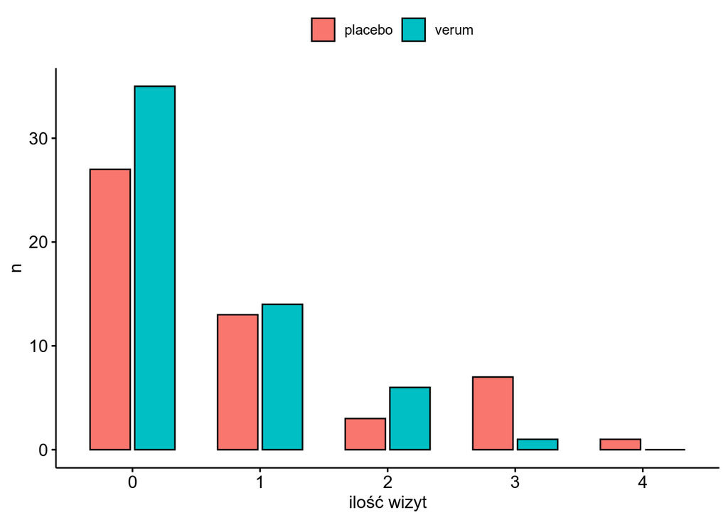

```r
table(df$`ilość wizyt ambulatoryjnych w ciągu ostatnich 3 miesięcy związanych z chorobą uchyłkową I jej zasotrzeniami/pwikłaniami`, df$grupa) %>%
  as.data.frame() %>%
  ggpubr::ggbarplot(x = "Var1",
                    y = "Freq",
                    fill = "Var2",
                    position = position_dodge2())+
  labs(x = "ilość wizyt",
       y = "n",
       fill = "")
```

```r
wilcox.test(`ilość wizyt ambulatoryjnych w ciągu ostatnich 3 miesięcy związanych z chorobą uchyłkową I jej zasotrzeniami/pwikłaniami`~grupa, data = df)
```

```
##
##  Wilcoxon rank sum test with continuity correction
##
## data:  ilość wizyt ambulatoryjnych w ciągu ostatnich 3 miesięcy związanych z chorobą uchyłkową I jej zasotrzeniami/pwikłaniami by grupa
## W = 1619, p-value = 0.1808
## alternative hypothesis: true location shift is not equal to 0
```

nie bylo roznic…

### - czy jest róznicą pomiędzy ilością hospitalizacji pomiędzy grupami żółta i zieloną (pewnie wyjdzie nieznamiennie)

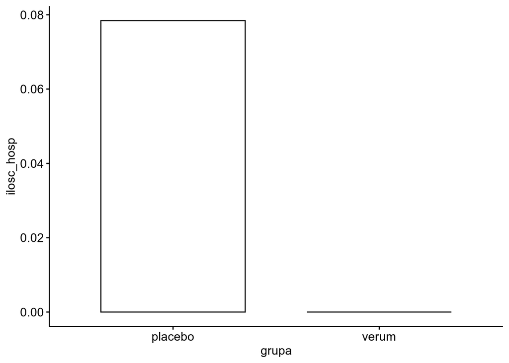

```r
df2 <- df %>%
  select(pacjent,
         grupa,`ilość hospitalizacji ciągu ostatnich 3 miesięcy związanych z chorobą uchyłkową I jej zasotrzeniami/pwikłaniami`) %>%
  mutate(ilosc_hosp = `ilość hospitalizacji ciągu ostatnich 3 miesięcy związanych z chorobą uchyłkową I jej zasotrzeniami/pwikłaniami`) %>%
  group_by(grupa) %>%
  summarise(ilosc_hosp = mean(ilosc_hosp,na.rm = T))

df2 %>%
ggpubr::ggbarplot(x = "grupa",
                   y = "ilosc_hosp")
```

```r
table(df$`ilość hospitalizacji ciągu ostatnich 3 miesięcy związanych z chorobą uchyłkową I jej zasotrzeniami/pwikłaniami`, df$grupa) %>%
  chisq.test()
```

```
##
##  Pearson's Chi-squared test with Yates' continuity correction
##
## data:  .
## X-squared = 2.6435, df = 1, p-value = 0.104
```

Nie było różnic między grupami jak chodzi o ilość hospitalizacji - pewnie rożnice by były istotne jak byśmy mieli więszką grupę badancyh i więcej udokumentoanych hospitalizacji u pacjentów z placebo bo w grupie z verum nie było wcale hospitalizacji…

### - ostatnia kolumna (X) dotyczy oceny subiektywnej pacjenta po terapii, czy jest róznica w tej ocenie pomiędzy grupą żółtą a zieloną

```r
t1 <- table(df$grupa, df$`Czy w opinii pacjenta samopoczucie związane z przewodem pokarmowym jest: 1) takie samo jak przed rozpoczęciem leczenia; 2) gorsze niż przed rozpoczęciem leczenia; 3) lepsze niż przed rozpoczęciem leczenia`)

t1
```

```
##
##            1  2  3
##   placebo 23  2 26
##   verum   31  0 26
```

```r
prop.table(t1,1)
```

```
##
##                    1          2          3
##   placebo 0.45098039 0.03921569 0.50980392
##   verum   0.54385965 0.00000000 0.45614035
```

## mamy BMI - czy można zobaczyć osobno dla grup żółtej i zielonej czy jest korelacja między wynikami leczenia (bóle, jakośc życia, ocena subiektywna pacjenta) a BMI?

Mamy BMI ale tylko wyjściowe. BMI po 3 Miesiącach nie było oznaczone - dlatego korelacja może jedynie odbyć się do BMI na wyjściu co znacznie ogranicza analizę. myślę że nie będzie to wystarczajće dla oodzielnej publikacji. Mam to liczyć?

Pozdrawiam

Wojtek